# Monitoria 9

Sinara

2024-05-10

1. Introdução

Vamos supor que se deseja conhecer um parâmetro θ de certa característica de uma população representada por uma variável aleatória X com função densidade f(x;θ). Na estimação pontual, o valor de alguma estatística t(X1,X2,…,Xn) estima o parâmetro desconhecido θ.

Exemplo: Suponha uma urna que contém bolas pretas e brancas e que a razão entre elas é de 3/1, mas não sabemos se há mais bolas pretas ou brancas. Assim, a probabilidade de retirar uma bola preta é 1/4 ou 3/4.

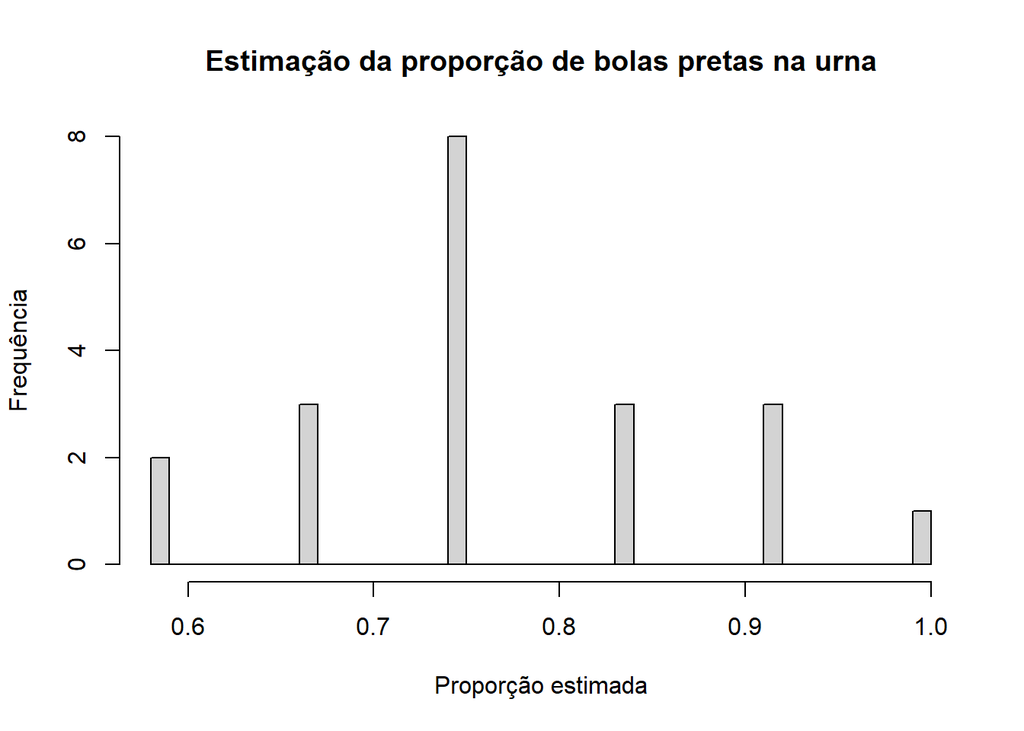

```r
# Parâmetros do problema
set.seed(123)
num_simulacoes <- 20
proporcao_real_bolas_pretas <- 0.75
tamanho_amostra <- 12

# Simulação e estimação da proporção de bolas pretas na urna
proporcoes_estimadas <- replicate(num_simulacoes, {
  amostra <- sample(c("preta", "branca"), size = tamanho_amostra, replace = TRUE, prob = c(proporcao_real_bolas_pretas, 1 - proporcao_real_bolas_pretas))
  mean(amostra == "preta")
})

# Histograma das proporções estimadas
hist(proporcoes_estimadas, breaks = 40, main = "Estimação da proporção de bolas pretas na urna", xlab = "Proporção estimada", ylab = "Frequência")
```

```r
# Média das proporções estimadas
mean(proporcoes_estimadas)
```

```
## [1] 0.7708333
```

OBS: Quanto maior a amostra, mais próxima da média real se torna a média calculada.

2. Função de densidade de probabilidade (pdf) conjunta

   Dizemos que X e Y são variáveis aleatórias independentes se a função densidade conjunta for o produto das densidades individuais, ou seja, f(x, y) = fX(x).fY(y)

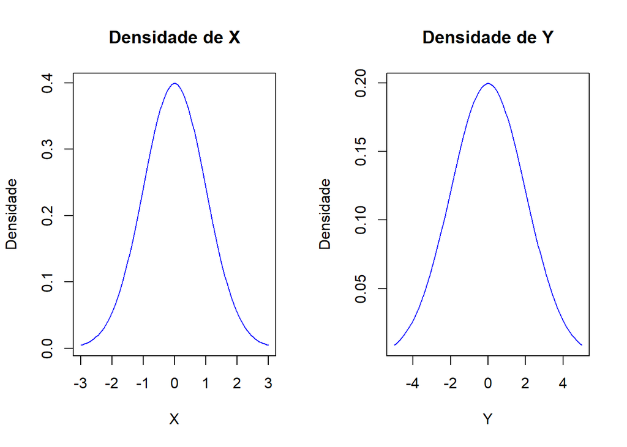

```r
library(ggplot2)

# Parâmetros das distribuições de X e Y
media_X <- 0
desvio_X <- 1
media_Y <- 0
desvio_Y <- 2

# Valores de x e y
x_vals <- seq(-3, 3, length.out = 100)
y_vals <- seq(-5, 5, length.out = 100)

# Densidades individuais para X e Y
dens_X <- dnorm(x_vals, mean = media_X, sd = desvio_X)
dens_Y <- dnorm(y_vals, mean = media_Y, sd = desvio_Y)
par(mfrow = c(1, 2))
plot(x_vals, dens_X, type = 'l', main = 'Densidade de X', xlab = 'X', ylab = 'Densidade', col = 'blue')
plot(y_vals, dens_Y, type = 'l', main = 'Densidade de Y', xlab = 'Y', ylab = 'Densidade', col = 'blue')
```

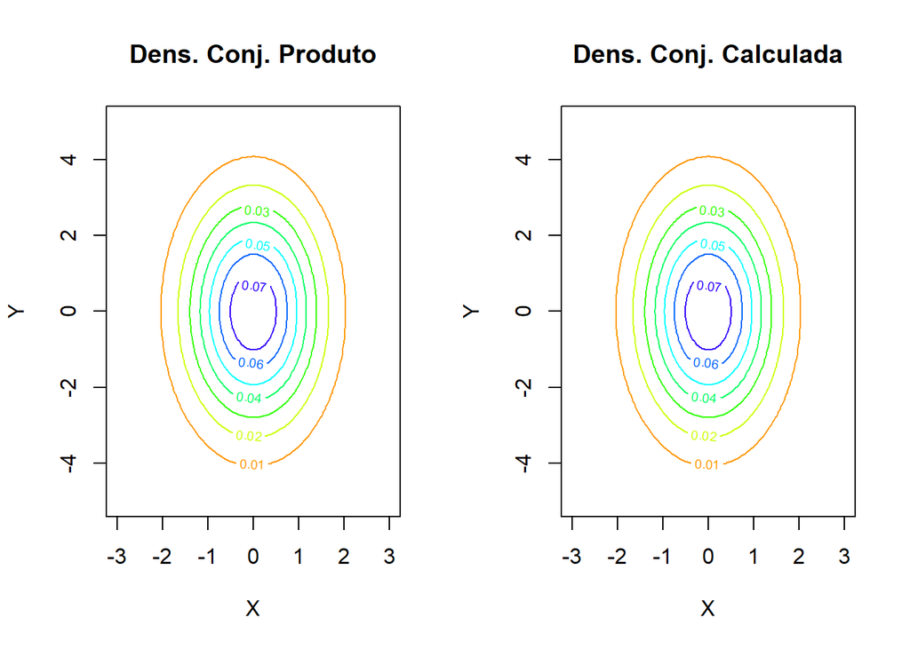

```r
# Densidade conjunta como o produto das densidades individuais
dens_conjunta <- outer(dens_X, dens_Y, "*")
contour(x_vals, y_vals, dens_conjunta, main = 'Dens. Conj. Produto', xlab = 'X', ylab = 'Y', col = rainbow(10))

# Densidade conjunta usando a função de densidade conjunta
dens_conjunta_calculada <- outer(dnorm(x_vals, media_X, desvio_X), dnorm(y_vals, media_Y, desvio_Y), "*")
contour(x_vals, y_vals, dens_conjunta_calculada, main = 'Dens. Conj. Calculada', xlab = 'X', ylab = 'Y', col = rainbow(10))
```

3. Função de Verossimilhança

   Para uma amostra aleatória (y1, …, yn), a pdf conjunta vista como uma função do vetor de parâmetros desconhecidos θ é denominada de *função de verossimilhança*.

   A função de verossimilhança L(θ|Y) representa a probabilidade dos dados observados Y como uma função dos parâmetros θ. L(θ∣Y)=f(Y∣θ). Em muitos casos, é mais conveniente trabalhar com a log-verossimilhança.

O objetivo da função de verossimilhança é avaliar como a probabilidade dos dados varia com diferentes valores do parâmetro θ.

O estimador θˆ é consistente e assintoticamente eficiente.

4. Maximização da Verossimilhança

4.1. Como funciona a maximização da Verossimilhança?

O Método da MV encontra o valor θˆ de θ que é o mais verossímil possível tendo em vista os dados à mão. Ou seja, o estimador θˆ maximiza a probabilidade de gerar os dados que realmente temos.

A maximização da verossimilhança costuma ser resolver uma otimização para encontrar os valores de θ que maximizam a função de verossimilhança. A resolução do problema consiste em “tentar” valores para o parâmetro até que um critério de convergência seja atendido.

4.2. Exemplos de estimação

4.2.1. Comparação Regressão Linear por OLS x MV

```r
# Dados de exemplo
set.seed(123)
x <- rnorm(1000, mean = 5, sd = 2)
y <- 2 + 0.5 * x + rnorm(1000, mean = 0, sd = 1)

# Mínimos Quadrados Ordinários
modelo_mqo <- lm(y ~ x)
summary(modelo_mqo)
```

```
##
## Call:
## lm(formula = y ~ x)
##
## Residuals:
##     Min      1Q  Median      3Q     Max
## -3.0279 -0.6914  0.0043  0.7087  3.2911
##
## Coefficients:
##             Estimate Std. Error t value Pr(>|t|)
## (Intercept)  1.82093    0.08683   20.97   <2e-16 ***
## x            0.54402    0.01605   33.89   <2e-16 ***
## ---
## Signif. codes:  0 '***' 0.001 '**' 0.01 '*' 0.05 '.' 0.1 ' ' 1
##
## Residual standard error: 1.006 on 998 degrees of freedom
## Multiple R-squared:  0.535,  Adjusted R-squared:  0.5346
## F-statistic:  1148 on 1 and 998 DF,  p-value: < 2.2e-16
```

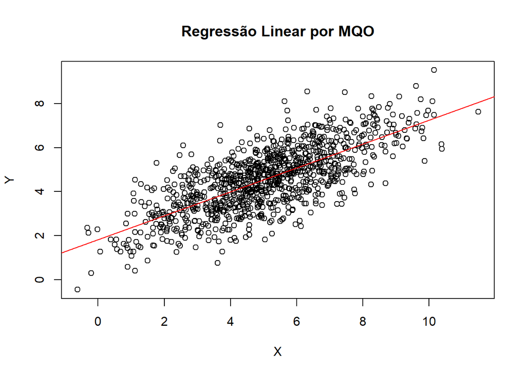

```r
plot(x, y, main = "Regressão Linear por MQO", xlab = "X", ylab = "Y")
abline(modelo_mqo, col = "red")
```

```r
# Máxima Verossimilhança
library(MASS)
modelo_mv <- glm(y ~ x, family = gaussian(link = "identity"))
summary(modelo_mv)
```

```
##
## Call:
## glm(formula = y ~ x, family = gaussian(link = "identity"))
##
## Coefficients:
##             Estimate Std. Error t value Pr(>|t|)
## (Intercept)  1.82093    0.08683   20.97   <2e-16 ***
## x            0.54402    0.01605   33.89   <2e-16 ***
## ---
## Signif. codes:  0 '***' 0.001 '**' 0.01 '*' 0.05 '.' 0.1 ' ' 1
##
## (Dispersion parameter for gaussian family taken to be 1.012832)
##
##     Null deviance: 2173.9  on 999  degrees of freedom
## Residual deviance: 1010.8  on 998  degrees of freedom
## AIC: 2854.6
##
## Number of Fisher Scoring iterations: 2
```

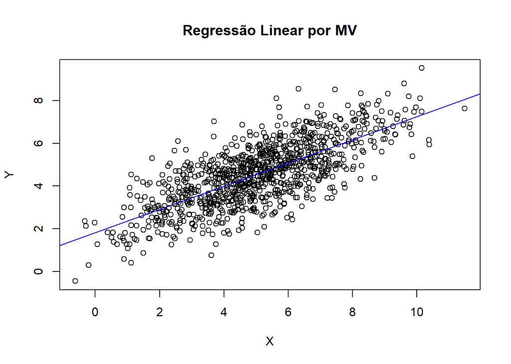

```r
plot(x, y, main = "Regressão Linear por MV", xlab = "X", ylab = "Y")
abline(coef(modelo_mv), col = "blue")
```

4.2.2. Regressão logística

```r
# Dados de exemplo
set.seed(123)
x <- rnorm(1000, mean = 0, sd = 1)
y <- rbinom(1000, size = 1, prob = plogis(0.5 + 0.8 * x))  # Variável dependente binária

# Ajustar o modelo de regressão logística
modelo_mv_lg <- glm(y ~ x, family = binomial(link = "logit"))
summary(modelo_mv_lg)
```

```
##
## Call:
## glm(formula = y ~ x, family = binomial(link = "logit"))
##
## Coefficients:
##             Estimate Std. Error z value Pr(>|z|)
## (Intercept)  0.49917    0.06916   7.218 5.29e-13 ***
## x            0.73716    0.07696   9.578  < 2e-16 ***
## ---
## Signif. codes:  0 '***' 0.001 '**' 0.01 '*' 0.05 '.' 0.1 ' ' 1
##
## (Dispersion parameter for binomial family taken to be 1)
##
##     Null deviance: 1335.7  on 999  degrees of freedom
## Residual deviance: 1228.5  on 998  degrees of freedom
## AIC: 1232.5
##
## Number of Fisher Scoring iterations: 4
```

4.3. Regressão de poisson

```r
# Dados de exemplo
set.seed(123)
x <- rnorm(1000, mean = 2, sd = 1)
y <- rpois(1000, exp(0.5 + 0.6 * x))  # Variável dependente com distribuição Poisson

# Ajustar o modelo de regressão de Poisson
modelo_mv_ps <- glm(y ~ x, family = poisson(link = "log"))
summary(modelo_mv_ps)
```

```
##
## Call:
## glm(formula = y ~ x, family = poisson(link = "log"))
##
## Coefficients:
##             Estimate Std. Error z value Pr(>|z|)
## (Intercept)  0.51076    0.03436   14.87   <2e-16 ***
## x            0.59503    0.01229   48.40   <2e-16 ***
## ---
## Signif. codes:  0 '***' 0.001 '**' 0.01 '*' 0.05 '.' 0.1 ' ' 1
##
## (Dispersion parameter for poisson family taken to be 1)
##
##     Null deviance: 3393.0  on 999  degrees of freedom
## Residual deviance: 1058.5  on 998  degrees of freedom
## AIC: 4516.4
##
## Number of Fisher Scoring iterations: 4
```

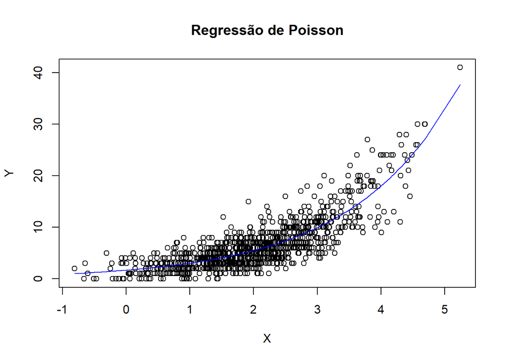

```r
plot(x, y, main = "Regressão de Poisson", xlab = "X", ylab = "Y")
lines(sort(x), predict(modelo_mv_ps, data.frame(x = sort(x)), type = "response"), col = "blue")
```

5. Função de Verossimilhança concentrada

É uma versão modificada da função de verossimilhança que se concentra apenas nos parâmetros de interesse da função de verossimilhança. Vantagem: facilidade de otimizar. Costuma-se realizar uma análise de sensibilidade, investigando-se como a função de verossimilhança e as estimativas dos parâmetros mudam quando os parâmetros são fixados ou modificados.

```r
# Dados de exemplo
set.seed(123)
x <- runif(1000, 0, 10)
beta0 <- 2
beta1 <- 1.5
sigma <- 2
epsilon <- rnorm(1000, 0, sigma)
y <- beta0 + beta1 * x + epsilon

# Definir a função de verossimilhança concentrada
funcao_verossimilhanca <- function(beta1, y, x, sigma) {
  soma <- sum((y - (beta0 + beta1 * x))^2) / (2 * sigma^2)
  return(-soma)
}

# Estimar beta1 por otimização com método "Brent"
resultado <- optimize(f = funcao_verossimilhanca, interval = c(-10, 10), y = y, x = x, sigma = sigma, maximum = TRUE)

# Resultado beta1
resultado$maximum
```

```
## [1] 1.500678
```

6. Testes de hipóteses baseados no princípio da Máxima Verossimilhança

6.1. Teste da Razão da Verossimilhança (LR)

Depois de estimar um modelo *restrito* (parâmetros ~θ) e um *irrestrito* (parâmetros ^θ) e testamos a H0: h(~θ) = 0. Se a restrição for verdadeira, o valor da função de verossimilhança avaliada em ~θ e ^θ devem estar próximos, indicando que a restrição faz sentido.

```r
library(lmtest)
# Dados de exemplo
set.seed(123)
x1 <- rnorm(1000, mean = 5, sd = 2)
x2 <- rnorm(1000, mean = 9, sd = 3)
y <- 2 + 0.5 * x1 + 0.2 * x2 + rnorm(1000, mean = 0, sd = 1)

# Modelos
modelo_irrestrito <- glm(y ~ x1 + x2, family = gaussian(link = "identity"))
modelo_restrito <- glm(y ~ 1, family = gaussian(link = "identity"))

# Teste LR entre modelos
teste_lr <- lrtest(modelo_restrito, modelo_irrestrito)
teste_lr
```

```
## Likelihood ratio test
##
## Model 1: y ~ 1
## Model 2: y ~ x1 + x2
##   #Df  LogLik Df  Chisq Pr(>Chisq)
## 1   2 -1857.3
## 2   4 -1396.0  2 922.68  < 2.2e-16 ***
## ---
## Signif. codes:  0 '***' 0.001 '**' 0.01 '*' 0.05 '.' 0.1 ' ' 1
```

6.2. Teste Wald

Estimamos *apenas o modelo irrestrito* e identificamos se ele está perto de cumprir a restrição. H0: h(^θ) = 0

```r
# Teste Wald para o coeficiente de x1 no modelo completo
teste_wald_x1 <- waldtest(modelo_irrestrito, "x1")
teste_wald_x1
```

```
## Wald test
##
## Model 1: y ~ x1 + x2
## Model 2: y ~ x2
##   Res.Df Df      F    Pr(>F)
## 1    997
## 2    998 -1 974.62 < 2.2e-16 ***
## ---
## Signif. codes:  0 '***' 0.001 '**' 0.01 '*' 0.05 '.' 0.1 ' ' 1
```

```r
teste_wald_x2 <- waldtest(modelo_irrestrito, "x2")
teste_wald_x2
```

```
## Wald test
##
## Model 1: y ~ x1 + x2
## Model 2: y ~ x1
##   Res.Df Df      F    Pr(>F)
## 1    997
## 2    998 -1 415.48 < 2.2e-16 ***
## ---
## Signif. codes:  0 '***' 0.001 '**' 0.01 '*' 0.05 '.' 0.1 ' ' 1
```

6.3. Multiplicador de Lagrange ou Escore Eficiente (LM)

Estimamos *apenas o modelo restrito*. Ou seja, devemos precisamos solucionar um problema de maximização condicionada. H0: h(~θ) = 0; A restrição é válida.

Ressalta-se que os três testes são assintoticamente equivalentes.

REFERÊNCIAS

Estimador de Máxima Verossimilhança. Disponível em: https://edisciplinas.usp.br/pluginfile.php/5891865/mod_resource/content/1/Aula%2015.pdf. Acesso em: 10 de maio de 2024.

PORTUGAL, Marcelo S. Notas Introdutórias Sobre o Princípio de Máxima Verossimilhança: Estimação e Teste de Hipóteses. Disponível em: http://www.agg.ufba.br/maximavrossi.pdf. Acesso em: 11 de maio de 2024.

IME USP. Princípio de Máxima Verossimilhança. Disponível em: https://www.ime.usp.br/~belitsky/wiki/lib/exe/fetch.php?media=teaching:teste_hip_proporcao_completo.pdf. Acesso em: 11 de maio de 2024.

PUC Rio. Distribuição de probabilidade conjunta. Disponível em: https://www.maxwell.vrac.puc-rio.br/129/129_001.HTM. Acesso em: 10 de maio de 2024.

STEENBERGEN, Marco R. Maximum Likelihood Programming in R. Disponível em: https://www.ime.unicamp.br/~cnaber/optim_1.pdf. Acesso em: 10 de maio de 2024.